# Lotka Volterra Fishing · Corleone.jl

## Lotka-Volterra Fishing Problem

This is a quick intro based on [the lotka volterra fishing problem](https://mintoc.de/index.php?title=Lotka_Volterra_fishing_problem).

## Setup

We will use `Corleone` to define our optimal control problem.

```julia
using Corleone
```

Additionally, we will need the folllowing packages

- `LuxCore` and `Random` for basic setup functions
- `OrdinaryDiffEqTsit5` as an adaptive solver for the related ODEProblem
- `SymbolicIndexingInterface` to conviniently access variables and controls of the solution
- `Optimization`, `OptimizationMOI`, `Ipopt`, and `ComponentArrays` to setup and solve the optimization problem
- `CairoMakie` to plot the solution

```julia
using LuxCore
using Random
using OrdinaryDiffEqTsit5
using SymbolicIndexingInterface
using Optimization
using OptimizationMOI
using Ipopt
using ComponentArrays
using CairoMakie
```

## Lotka Volterrra Dynamics

First, in the ODEProblem has to be defined in a standard way.

```julia
function lotka_dynamics(du, u, p, t)
    du[1] = u[1] - p[2] * prod(u[1:2]) - 0.4 * p[1] * u[1]
    du[2] = -u[2] + p[3] * prod(u[1:2]) - 0.2 * p[1] * u[2]
    return du[3] = (u[1] - 1.0)^2 + (u[2] - 1.0)^2
end
tspan = (0.0, 12.0)
u0 = [0.5, 0.7, 0.0]
p0 = [0.0, 1.0, 1.0]
prob = ODEProblem(lotka_dynamics, u0, tspan, p0)
```

```
ODEProblem with uType Vector{Float64} and tType Float64. In-place: true
Non-trivial mass matrix: false
timespan: (0.0, 12.0)
u0: 3-element Vector{Float64}:
 0.5
 0.7
 0.0
```

## Single Shooting Approach

Then, as shown before in the LQR example, the discretized control needs to be defined and applied to the problem by constructing a `SingleShootingLayer`

```julia
cgrid = collect(0.0:0.1:11.9)
control = ControlParameter(
    cgrid, name=:fishing, bounds=(0.0, 1.0), controls=ones(length(cgrid))
)
layer = Corleone.SingleShootingLayer(prob, Tsit5(), controls=(1 => control,), bounds_p=([1.0, 1.0], [1.0, 1.0]))

function plot_lotka(sol)
    f = Figure()
    ax = CairoMakie.Axis(f[1, 1])
    scatterlines!(ax, sol, vars=[:x₁, :x₂])
    f[1, 2] = Legend(f, ax, "States", framevisible=false)
    ax1 = CairoMakie.Axis(f[2, 1])
    stairs!(ax1, sol, vars=[:fishing])
    f[2, 2] = Legend(f, ax1, "Controls", framevisible=false)
    f
end
```

```
plot_lotka (generic function with 1 method)
```

The OptimizationProblem minimizing the terminal value of state `x₃` is easily set up and solved.

```julia
optprob = OptimizationProblem(layer, :x₃)
uopt = solve(
    optprob, Ipopt.Optimizer(),
    tol=1.0e-6,
    hessian_approximation="limited-memory",
    max_iter=300
);
```

```
******************************************************************************
This program contains Ipopt, a library for large-scale nonlinear optimization.
 Ipopt is released as open source code under the Eclipse Public License (EPL).
         For more information visit https://github.com/coin-or/Ipopt
******************************************************************************

This is Ipopt version 3.14.19, running with linear solver MUMPS 5.8.2.

Number of nonzeros in equality constraint Jacobian...:        0
Number of nonzeros in inequality constraint Jacobian.:        0
Number of nonzeros in Lagrangian Hessian.............:        0

Total number of variables............................:      120
                     variables with only lower bounds:        0
                variables with lower and upper bounds:      120
                     variables with only upper bounds:        0
Total number of equality constraints.................:        0
Total number of inequality constraints...............:        0
        inequality constraints with only lower bounds:        0
   inequality constraints with lower and upper bounds:        0
        inequality constraints with only upper bounds:        0

iter    objective    inf_pr   inf_du lg(mu)  ||d||  lg(rg) alpha_du alpha_pr  ls
   0  9.3555088e+00 0.00e+00 4.50e-01   0.0 0.00e+00    -  0.00e+00 0.00e+00   0
   1  8.8025628e+00 0.00e+00 2.58e-01  -0.8 1.51e-01    -  9.96e-01 1.00e+00f  1
   2  3.4618539e+00 0.00e+00 2.54e-01  -1.2 1.52e+00    -  9.26e-01 5.47e-01f  1
   3  2.4303981e+00 0.00e+00 2.37e-01  -1.8 4.57e-01    -  9.79e-01 1.00e+00f  1
   4  2.0495594e+00 0.00e+00 8.41e-02  -2.1 1.33e-01    -  9.90e-01 1.00e+00f  1
   5  1.7065566e+00 0.00e+00 3.37e-02  -2.3 2.41e-01    -  9.78e-01 1.00e+00f  1
   6  1.5045501e+00 0.00e+00 3.03e-02  -2.9 2.26e-01    -  9.88e-01 1.00e+00f  1
   7  1.3962652e+00 0.00e+00 2.17e-02  -3.5 2.08e-01    -  1.00e+00 8.86e-01f  1
   8  1.3710133e+00 0.00e+00 2.06e-02  -4.0 2.40e-01    -  1.00e+00 5.63e-01f  1
   9  1.3601040e+00 0.00e+00 1.27e-02  -3.9 3.49e-01    -  1.00e+00 4.31e-01f  1
iter    objective    inf_pr   inf_du lg(mu)  ||d||  lg(rg) alpha_du alpha_pr  ls
  10  1.3544968e+00 0.00e+00 3.79e-03  -4.3 2.16e-01    -  1.00e+00 4.23e-01f  1
  11  1.3491980e+00 0.00e+00 3.48e-03  -5.2 2.70e-01    -  9.98e-01 5.50e-01f  1
  12  1.3465288e+00 0.00e+00 4.64e-03  -5.3 5.12e-01    -  1.00e+00 4.55e-01f  1
  13  1.3463491e+00 0.00e+00 2.22e-03  -5.5 1.48e-01    -  1.00e+00 6.29e-02f  3
  14  1.3451740e+00 0.00e+00 4.07e-03  -5.3 1.19e-02    -  1.00e+00 9.80e-01f  1
  15  1.3447077e+00 0.00e+00 8.33e-04  -6.5 3.37e-02    -  1.00e+00 6.66e-01f  1
  16  1.3445826e+00 0.00e+00 2.04e-03  -8.1 4.15e-02    -  1.00e+00 5.80e-01f  1
  17  1.3445024e+00 0.00e+00 1.05e-03  -8.4 7.26e-02    -  1.00e+00 2.06e-01f  1
  18  1.3444366e+00 0.00e+00 3.91e-04  -7.6 3.17e-02    -  1.00e+00 6.63e-01f  1
  19  1.3444269e+00 0.00e+00 3.04e-04  -6.8 4.45e-02    -  1.00e+00 1.89e-01f  1
iter    objective    inf_pr   inf_du lg(mu)  ||d||  lg(rg) alpha_du alpha_pr  ls
  20  1.3444038e+00 0.00e+00 1.43e-03  -7.5 1.55e-01    -  1.00e+00 2.88e-01f  1
  21  1.3443808e+00 0.00e+00 1.13e-03  -8.0 9.07e-02    -  1.00e+00 7.67e-01f  1
  22  1.3443869e+00 0.00e+00 2.84e-04  -6.6 6.54e-02    -  9.87e-01 1.00e+00f  1
  23  1.3443875e+00 0.00e+00 3.28e-04  -6.5 1.57e-01    -  1.00e+00 3.12e-02f  6
  24  1.3443776e+00 0.00e+00 2.80e-04  -6.5 1.14e-01    -  1.00e+00 1.94e-01f  2
  25  1.3443650e+00 0.00e+00 8.86e-04  -6.8 6.23e-02    -  1.00e+00 8.62e-01f  1
  26  1.3443556e+00 0.00e+00 5.60e-04  -7.5 1.05e-01    -  1.00e+00 1.36e-01f  2
  27  1.3443462e+00 0.00e+00 1.05e-04  -7.9 1.48e-02    -  1.00e+00 7.18e-01f  1
  28  1.3443448e+00 0.00e+00 1.76e-04  -7.4 1.63e-02    -  1.00e+00 5.00e-01f  2
  29  1.3443416e+00 0.00e+00 5.35e-05  -8.4 5.35e-03    -  1.00e+00 1.00e+00f  1
iter    objective    inf_pr   inf_du lg(mu)  ||d||  lg(rg) alpha_du alpha_pr  ls
  30  1.3443414e+00 0.00e+00 8.84e-05 -10.0 1.11e-02    -  1.00e+00 7.04e-01f  1
  31  1.3443402e+00 0.00e+00 1.10e-04  -8.6 3.22e-02    -  1.00e+00 4.99e-01f  1
  32  1.3443399e+00 0.00e+00 8.14e-05 -10.1 9.05e-03    -  1.00e+00 5.14e-01f  1
  33  1.3443398e+00 0.00e+00 1.68e-04  -9.3 3.47e-03    -  1.00e+00 2.50e-01f  3
  34  1.3443395e+00 0.00e+00 1.39e-04  -8.6 1.02e-03    -  1.00e+00 1.00e+00f  1
  35  1.3443393e+00 0.00e+00 2.37e-05 -11.0 1.39e-03    -  1.00e+00 7.12e-01f  1
  36  1.3443391e+00 0.00e+00 2.33e-05 -11.0 3.58e-03    -  1.00e+00 7.59e-01f  1
  37  1.3443391e+00 0.00e+00 3.46e-05 -11.0 2.75e-02    -  1.00e+00 1.90e-01f  1
  38  1.3443389e+00 0.00e+00 1.24e-04  -9.4 2.92e-02    -  1.00e+00 2.50e-01f  3
  39  1.3443388e+00 0.00e+00 8.15e-05  -9.2 5.31e-01    -  1.00e+00 5.54e-02f  2
iter    objective    inf_pr   inf_du lg(mu)  ||d||  lg(rg) alpha_du alpha_pr  ls
  40  1.3443387e+00 0.00e+00 6.77e-05  -9.6 8.25e-02    -  1.00e+00 2.82e-02f  4
  41  1.3443388e+00 0.00e+00 1.66e-04  -8.1 3.23e-02    -  1.00e+00 2.50e-01f  3
  42  1.3443384e+00 0.00e+00 5.77e-05  -8.3 1.11e-02    -  4.28e-01 5.00e-01f  2
  43  1.3443381e+00 0.00e+00 7.36e-05  -9.0 3.07e-03    -  1.00e+00 9.80e-01f  1
  44  1.3443379e+00 0.00e+00 7.39e-05  -9.7 2.06e-02    -  1.00e+00 2.90e-01f  2
  45  1.3443378e+00 0.00e+00 9.57e-05 -10.5 1.53e-02    -  1.00e+00 2.50e-01f  3
  46  1.3443377e+00 0.00e+00 7.79e-05 -10.5 1.61e-01    -  1.00e+00 3.98e-02f  4
  47  1.3443380e+00 0.00e+00 8.20e-05  -8.4 7.00e-02    -  1.00e+00 1.00e+00f  1
  48  1.3443380e+00 0.00e+00 1.23e-04  -8.5 4.19e-01    -  9.57e-02 4.88e-03f  5
  49  1.3443376e+00 0.00e+00 5.05e-05  -8.5 1.00e-02    -  1.00e+00 3.33e-01f  2
iter    objective    inf_pr   inf_du lg(mu)  ||d||  lg(rg) alpha_du alpha_pr  ls
  50  1.3443375e+00 0.00e+00 9.62e-05  -8.5 4.97e-02    -  1.00e+00 4.99e-01f  1
  51  1.3443371e+00 0.00e+00 5.28e-05  -8.2 2.19e-01    -  1.00e+00 1.76e-01f  2
  52  1.3443372e+00 0.00e+00 1.08e-04  -7.8 4.72e-02    -  1.00e+00 4.67e-02f  4
  53  1.3443372e+00 0.00e+00 4.78e-05  -7.9 1.03e-02    -  1.00e+00 1.25e-01f  4
  54  1.3443373e+00 0.00e+00 3.97e-05  -7.9 2.97e-03    -  1.00e+00 1.00e+00f  1
  55  1.3443372e+00 0.00e+00 8.06e-05  -7.9 5.09e-03    -  1.00e+00 1.00e+00f  1
  56  1.3443372e+00 0.00e+00 6.78e-05  -7.9 3.50e-02    -  9.15e-01 1.15e-01f  3
  57  1.3443371e+00 0.00e+00 2.30e-05  -7.9 2.45e-03    -  1.00e+00 1.00e+00f  1
  58  1.3443371e+00 0.00e+00 4.24e-05  -7.9 1.18e-02    -  1.00e+00 1.00e+00f  1
  59  1.3443371e+00 0.00e+00 1.83e-05  -7.9 7.37e-03    -  1.00e+00 2.50e-01f  3
iter    objective    inf_pr   inf_du lg(mu)  ||d||  lg(rg) alpha_du alpha_pr  ls
  60  1.3443370e+00 0.00e+00 5.01e-05  -8.7 5.41e-03    -  1.00e+00 1.25e-01f  4
  61  1.3443365e+00 0.00e+00 2.35e-05 -11.0 1.09e-03    -  1.00e+00 9.90e-01f  1
  62  1.3443365e+00 0.00e+00 7.11e-06 -10.2 2.31e-03    -  1.00e+00 9.40e-01f  1
  63  1.3443365e+00 0.00e+00 2.36e-05  -9.3 1.21e-02    -  1.00e+00 3.50e-02f  4
  64  1.3443365e+00 0.00e+00 2.92e-05  -9.1 1.93e-02    -  1.00e+00 2.78e-01f  1
  65  1.3443365e+00 0.00e+00 2.17e-05  -8.9 3.05e-02    -  1.00e+00 1.65e-01f  3
  66  1.3443365e+00 0.00e+00 3.50e-05  -8.7 2.49e-02    -  1.00e+00 3.03e-01f  2
  67  1.3443365e+00 0.00e+00 1.83e-05  -8.9 1.62e-02    -  3.78e-01 5.80e-02f  4
  68  1.3443365e+00 0.00e+00 3.09e-05  -8.9 5.51e-03    -  6.86e-01 5.00e-01f  2
  69  1.3443365e+00 0.00e+00 8.03e-06  -8.9 7.92e-03    -  1.00e+00 1.80e-01f  3
iter    objective    inf_pr   inf_du lg(mu)  ||d||  lg(rg) alpha_du alpha_pr  ls
  70  1.3443365e+00 0.00e+00 1.59e-05  -9.1 4.33e-03    -  1.00e+00 2.50e-01f  3
  71  1.3443365e+00 0.00e+00 1.30e-05  -8.9 5.82e-02    -  1.00e+00 4.17e-02f  3
  72  1.3443365e+00 0.00e+00 9.19e-06  -8.6 8.43e-03    -  1.00e+00 2.16e-01f  3
  73  1.3443365e+00 0.00e+00 1.65e-05  -8.8 3.95e-03    -  1.00e+00 5.00e-01f  2
  74  1.3443365e+00 0.00e+00 1.10e-05  -8.8 3.17e-03    -  6.96e-01 6.25e-02f  5
  75  1.3443365e+00 0.00e+00 1.10e-05  -8.8 1.09e-03    -  1.00e+00 5.00e-01f  2
  76  1.3443365e+00 0.00e+00 8.09e-06  -8.8 5.81e-04    -  1.00e+00 5.00e-01f  2
  77  1.3443365e+00 0.00e+00 1.88e-05  -8.8 5.45e-04    -  1.00e+00 1.00e+00f  1
  78  1.3443365e+00 0.00e+00 5.74e-06  -8.8 1.82e-03    -  1.00e+00 6.25e-02f  5
  79  1.3443365e+00 0.00e+00 3.47e-06  -8.8 2.91e-04    -  1.00e+00 1.00e+00f  1
iter    objective    inf_pr   inf_du lg(mu)  ||d||  lg(rg) alpha_du alpha_pr  ls
  80  1.3443365e+00 0.00e+00 7.02e-06  -8.8 7.46e-04    -  1.00e+00 1.00e+00f  1
  81  1.3443365e+00 0.00e+00 1.20e-05  -8.5 1.63e-02    -  1.00e+00 2.82e-02f  5
  82  1.3443365e+00 0.00e+00 9.46e-06  -8.6 4.54e-03    -  1.00e+00 5.00e-01f  2
  83  1.3443365e+00 0.00e+00 6.00e-06  -8.6 7.43e-03    -  1.00e+00 6.25e-02f  5
  84  1.3443365e+00 0.00e+00 5.64e-06  -8.6 4.85e-04    -  1.00e+00 5.00e-01f  2
  85  1.3443365e+00 0.00e+00 1.17e-05  -8.6 9.97e-04    -  1.00e+00 6.25e-02f  5
  86  1.3443365e+00 0.00e+00 2.25e-06  -8.6 3.55e-04    -  1.00e+00 1.00e+00f  1
  87  1.3443365e+00 0.00e+00 4.38e-06  -8.6 3.34e-04    -  1.00e+00 1.00e+00f  1
  88  1.3443365e+00 0.00e+00 9.77e-06  -8.6 8.36e-03    -  1.00e+00 2.50e-01f  3
  89  1.3443365e+00 0.00e+00 1.07e-05  -8.6 3.35e-01    -  1.66e-01 1.05e-02f  6
iter    objective    inf_pr   inf_du lg(mu)  ||d||  lg(rg) alpha_du alpha_pr  ls
  90  1.3443365e+00 0.00e+00 7.57e-06  -8.6 1.20e-02    -  1.00e+00 1.25e-01f  4
  91  1.3443365e+00 0.00e+00 7.84e-06  -8.6 3.54e-03    -  1.00e+00 6.25e-02f  5
  92  1.3443365e+00 0.00e+00 9.65e-06  -8.6 2.71e-03    -  1.00e+00 3.12e-02f  6
  93  1.3443365e+00 0.00e+00 5.83e-06  -8.6 1.91e-03    -  1.00e+00 1.25e-01f  4
  94  1.3443365e+00 0.00e+00 4.38e-06  -8.6 1.36e-03    -  1.00e+00 5.00e-01f  2
  95  1.3443365e+00 0.00e+00 3.01e-06  -8.6 2.45e-03    -  1.00e+00 2.50e-01f  3
  96  1.3443365e+00 0.00e+00 5.27e-06  -8.6 2.18e-03    -  1.00e+00 6.25e-02f  5
  97  1.3443365e+00 0.00e+00 4.31e-06  -8.6 1.79e-03    -  1.00e+00 5.00e-01f  2
  98  1.3443366e+00 0.00e+00 1.98e-05  -8.6 5.94e-03    -  1.00e+00 1.00e+00w  1
  99  1.3443367e+00 0.00e+00 9.81e-05  -8.6 4.77e-03    -  1.00e+00 1.00e+00w  1
iter    objective    inf_pr   inf_du lg(mu)  ||d||  lg(rg) alpha_du alpha_pr  ls
 100  1.3443386e+00 0.00e+00 3.06e-04  -8.6 1.71e-02    -  1.00e+00 4.73e-01w  1
 101  1.3443365e+00 0.00e+00 3.93e-06  -8.6 1.37e-02    -  1.00e+00 1.25e-01f  3
 102  1.3443365e+00 0.00e+00 6.61e-06  -8.6 3.18e-03    -  1.00e+00 5.00e-01f  2
 103  1.3443365e+00 0.00e+00 3.32e-06  -8.6 7.70e-02    -  4.13e-01 1.20e-02f  7
 104  1.3443365e+00 0.00e+00 4.54e-06  -8.6 5.54e-02    -  1.00e+00 3.12e-02f  6
 105  1.3443365e+00 0.00e+00 5.25e-06  -8.6 1.25e-02    -  1.00e+00 3.12e-02f  6
 106  1.3443365e+00 0.00e+00 3.73e-06  -8.6 7.04e-03    -  1.00e+00 6.25e-02f  5
 107  1.3443365e+00 0.00e+00 2.88e-06  -8.6 2.10e-03    -  1.00e+00 1.25e-01f  4
 108  1.3443365e+00 0.00e+00 3.42e-05  -9.8 9.67e-03    -  1.00e+00 5.00e-01f  2
 109  1.3443364e+00 0.00e+00 2.07e-05  -9.5 2.28e-02    -  1.00e+00 9.33e-02f  4
iter    objective    inf_pr   inf_du lg(mu)  ||d||  lg(rg) alpha_du alpha_pr  ls
 110  1.3443364e+00 0.00e+00 2.85e-05  -9.4 8.01e-02    -  1.00e+00 1.54e-02f  6
 111  1.3443364e+00 0.00e+00 2.12e-05  -9.6 4.90e-02    -  1.00e+00 6.25e-02f  5
 112  1.3443364e+00 0.00e+00 1.32e-05  -8.9 8.81e-03    -  1.00e+00 6.25e-02f  5
 113  1.3443364e+00 0.00e+00 2.47e-05 -10.1 4.21e-03    -  1.00e+00 2.50e-01f  3
 114  1.3443364e+00 0.00e+00 1.09e-05 -10.1 2.14e-02    -  1.00e+00 4.99e-01f  2
 115  1.3443364e+00 0.00e+00 2.00e-05  -9.5 1.81e-01    -  1.00e+00 1.77e-02f  6
 116  1.3443364e+00 0.00e+00 1.11e-05  -9.2 8.53e-02    -  1.00e+00 1.68e-02f  6
 117  1.3443364e+00 0.00e+00 1.01e-05  -9.4 5.68e-02    -  1.00e+00 1.48e-02f  7
 118  1.3443364e+00 0.00e+00 9.85e-06  -9.1 4.17e-02    -  1.00e+00 4.28e-02f  5
 119  1.3443364e+00 0.00e+00 1.00e-05 -10.0 9.80e-03    -  1.00e+00 2.50e-01f  3
iter    objective    inf_pr   inf_du lg(mu)  ||d||  lg(rg) alpha_du alpha_pr  ls
```

```
 120  1.3443364e+00 0.00e+00 2.08e-05  -9.0 1.41e-01    -  1.00e+00 1.04e-02f  6
 121  1.3443364e+00 0.00e+00 8.76e-06  -9.2 2.70e-01    -  1.00e+00 2.32e-02f  4
 122  1.3443364e+00 0.00e+00 6.27e-06  -9.5 1.08e-01    -  1.00e+00 1.56e-02f  7
 123  1.3443364e+00 0.00e+00 3.19e-05  -8.6 6.70e-02    -  1.00e+00 6.25e-02f  5
 124  1.3443364e+00 0.00e+00 1.99e-05  -8.8 1.78e-02    -  1.00e+00 1.25e-01f  4
 125  1.3443364e+00 0.00e+00 1.71e-05  -8.8 2.06e-02    -  1.00e+00 6.25e-02f  5
 126  1.3443365e+00 0.00e+00 7.71e-06  -8.8 1.67e-02    -  1.00e+00 1.00e+00f  1
 127  1.3443365e+00 0.00e+00 1.18e-05  -8.8 8.15e-02    -  1.00e+00 6.35e-03f  8
 128  1.3443365e+00 0.00e+00 1.02e-05  -8.8 3.48e-03    -  1.00e+00 1.25e-01f  4
 129  1.3443364e+00 0.00e+00 1.63e-05  -8.8 5.12e-03    -  1.00e+00 5.00e-01f  2
iter    objective    inf_pr   inf_du lg(mu)  ||d||  lg(rg) alpha_du alpha_pr  ls
 130  1.3443364e+00 0.00e+00 1.35e-05  -8.8 1.93e-02    -  1.00e+00 3.12e-02f  6
 131  1.3443364e+00 0.00e+00 1.22e-05  -8.8 2.06e-02    -  1.00e+00 6.25e-02f  5
 132  1.3443364e+00 0.00e+00 3.10e-06  -8.8 2.74e-02    -  1.00e+00 3.12e-02f  6
 133  1.3443364e+00 0.00e+00 3.87e-06  -8.8 5.13e-04    -  1.00e+00 1.00e+00f  1
 134  1.3443364e+00 0.00e+00 5.02e-06  -8.8 4.66e-04    -  1.00e+00 2.50e-01f  3
 135  1.3443364e+00 0.00e+00 2.65e-06  -8.8 1.14e-03    -  1.00e+00 1.25e-01f  4
 136  1.3443364e+00 0.00e+00 2.00e-06  -8.8 6.17e-05    -  1.00e+00 5.00e-01f  2
 137  1.3443364e+00 0.00e+00 1.73e-06  -8.8 2.73e-05    -  1.00e+00 1.00e+00f  1
 138  1.3443364e+00 0.00e+00 2.00e-06  -8.8 2.24e-04    -  1.00e+00 2.50e-01f  3
 139  1.3443364e+00 0.00e+00 7.77e-07  -8.8 1.93e-04    -  1.00e+00 2.50e-01f  3

Number of Iterations....: 139

                                   (scaled)                 (unscaled)
Objective...............:   1.3443364358708780e+00    1.3443364358708780e+00
Dual infeasibility......:   7.7650768909411091e-07    7.7650768909411091e-07
Constraint violation....:   0.0000000000000000e+00    0.0000000000000000e+00
Variable bound violation:   0.0000000000000000e+00    0.0000000000000000e+00
Complementarity.........:   1.6499796884278988e-09    1.6499796884278988e-09
Overall NLP error.......:   7.7650768909411091e-07    7.7650768909411091e-07


Number of objective function evaluations             = 732
Number of objective gradient evaluations             = 140
Number of equality constraint evaluations            = 0
Number of inequality constraint evaluations          = 0
Number of equality constraint Jacobian evaluations   = 0
Number of inequality constraint Jacobian evaluations = 0
Number of Lagrangian Hessian evaluations             = 0
Total seconds in IPOPT                               = 42.267

EXIT: Optimal Solution Found.
```

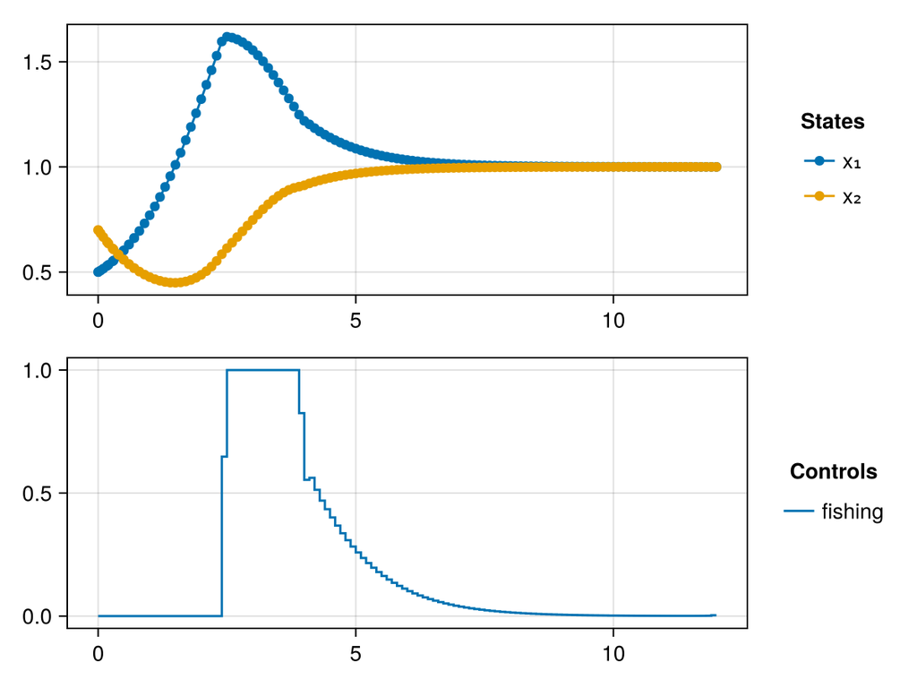

```julia
ps, st = LuxCore.setup(Random.default_rng(), layer)
optsol, _ = layer(nothing, uopt + zero(ComponentArray(ps)), st)

plot_lotka(optsol)
```

## Multiple Shooting

We can also partition the time horizon into smaller intervals on which the integration is decoupled. At these shooting points, variables are introduced for the initial values of the differential states. By this lifting approach, nonlinearities can be reduced. In `Corleone`, this can be done by constructing a `MultipleShootingLayer` from the `ODEProblem` and adding a vector of shooting points. The optimization problem is constructed in the same way as with the `SingleShootingLayer`. However, in the background matching constraints are added that require the final state on one shooting interval matches the initial state on the subsequent shooting interval.

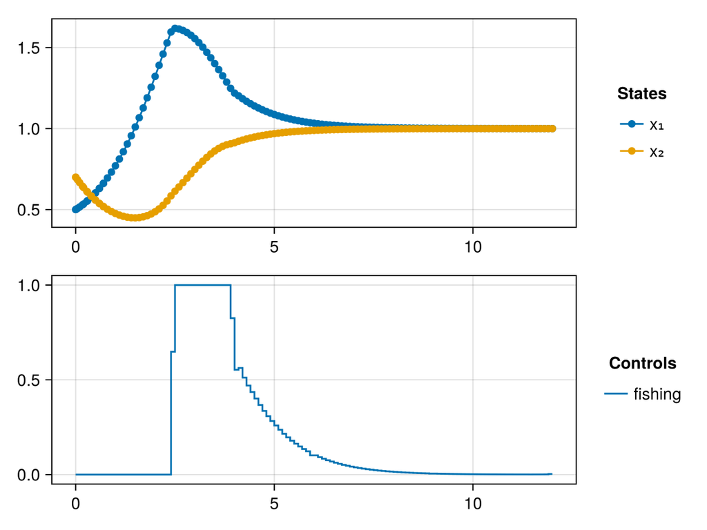

```julia
shooting_points = [0.0, 3.0, 6.0, 9.0, 12.0]
mslayer = MultipleShootingLayer(
    prob, Tsit5(), shooting_points...; controls=(1 => control,),
    bounds_p=([1.0, 1.0], [1.0, 1.0])
)

msps, msst = LuxCore.setup(Random.default_rng(), mslayer)

optprob = OptimizationProblem(
    mslayer, :x₃
)

uopt = solve(
    optprob, Ipopt.Optimizer(),
    tol=1.0e-5,
    hessian_approximation="limited-memory",
    max_iter=300
);

mssol, _ = mslayer(nothing, uopt + zero(ComponentArray(msps)), msst);

plot_lotka(mssol)
```

## Appendix

**This example was built using these direct dependencies,**

```julia
        using Pkg
        Pkg.status()
```

```
Status `~/work/Corleone.jl/Corleone.jl/docs/Project.toml`
  [13f3f980] CairoMakie v0.15.8
  [b0b7db55] ComponentArrays v0.15.32
  [2751e0db] Corleone v0.0.3 `~/work/Corleone.jl/Corleone.jl`
  [6590a4b1] CorleoneOED v0.0.2
  [e30172f5] Documenter v1.16.1
  [daee34ce] DocumenterCitations v1.4.1
  [d12716ef] DocumenterInterLinks v1.1.0
  [f6369f11] ForwardDiff v1.3.2
  [b6b21f68] Ipopt v1.14.0
  [682c06a0] JSON v1.4.0
  [98b081ad] Literate v2.21.0
  [bb33d45b] LuxCore v1.5.3
  [7f7a1694] Optimization v5.5.0
  [22f7324a] OptimizationLBFGSB v1.4.0
  [fd9f6733] OptimizationMOI v1.2.0
  [b1df2697] OrdinaryDiffEqTsit5 v1.9.0
  [2efcf032] SymbolicIndexingInterface v0.3.46
  [ddb6d928] YAML v0.4.16
  [9a3f8284] Random v1.11.0
```

**and using this machine and Julia version.**

```julia
        using InteractiveUtils
        InteractiveUtils.versioninfo()
```

```
Julia Version 1.12.5
Commit 5fe89b8ddc1 (2026-02-09 16:05 UTC)
Build Info:
  Official https://julialang.org release
Platform Info:
  OS: Linux (x86_64-linux-gnu)
  CPU: 4 × AMD EPYC 7763 64-Core Processor
  WORD_SIZE: 64
  LLVM: libLLVM-18.1.7 (ORCJIT, znver3)
  GC: Built with stock GC
Threads: 1 default, 1 interactive, 1 GC (on 4 virtual cores)
```

**A more complete overview of all dependencies and their versions is also provided.**

```julia
        using Pkg
        Pkg.status(; mode = PKGMODE_MANIFEST)
```

[output not shown]

[output not shown]

*This page was generated using Literate.jl.*